Cálculo de probabilidad de VAs

# Variables aleatorias discretas

Como se ha mencionado en clases pasadas existen tres tipos de variables aleatorias; discretas, continuas y mixtas. Para nuestro curso, estaremos interesados en las variables aleatorias discretas y continuas. Recordemos que para las variables aleatorias discretas contamos con dos funciones que las describen totalmente; la función de distribución y la función de densidad. La función de distribución está dada por:
$$F_X(x) = P(X \le x)$$
para cualquier valor $x \in \mathbb{R}$. La función de masa de probabilidad es la otra función que se define de la siguiente manera:
$$p_X(k) = P(X=k)$$
Por lo tanto, cuando se nos dá una variable aleatoria discreta ésta está definida por una fórmula que representa $p_X(k)$ o $F_X(x)$. La variable aleatoria binomial, por ejemplo está dada por:
$$p_X(k) = \binom{n}{k}p^k(1-p)^{n-k}\; \;\;\; k=0,1,2, \ldots n$$
En R, los comandos `dbinom, pbinom, rbinom` y `qbinom` generan las pmfs, distribuciones y números aleatorios relacionados a la variable aleatoria discreta Binomial. Por ejemplo, el siguiente código genera $100$ números aleatorios de una distriubción binomial con parámetros $n=16$, $p=0.1$ y posteriormente se grafican.

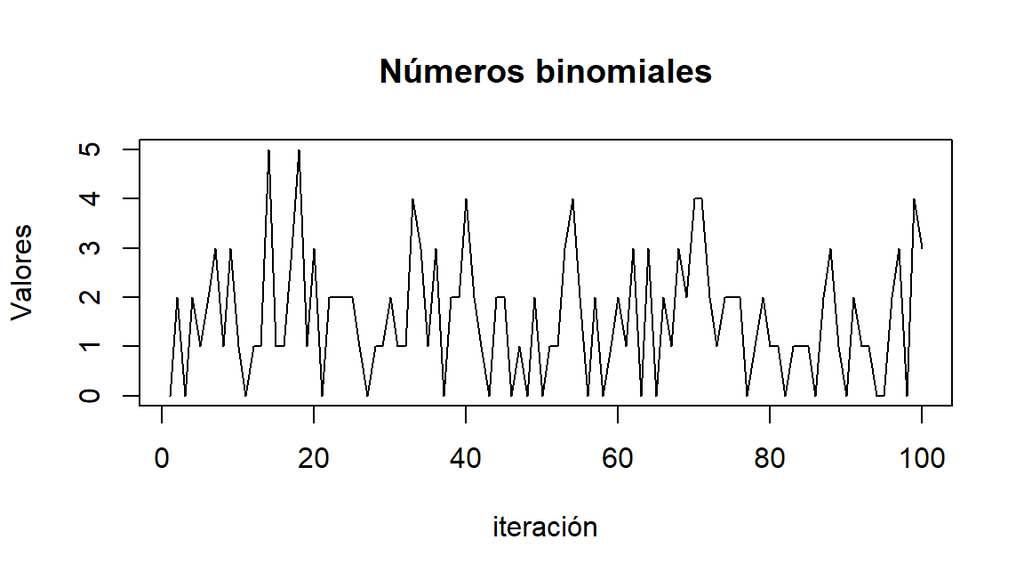

```r
vars <-rbinom(100, size=16, prob=0.1)
plot(vars, type="l", main="Números binomiales", xlab="iteración", ylab="Valores")
```

## Actividad

Investigue la generación de *pmfs* y *cdfs* discretas en R o python y posteriormente calcule las siguientes probabilidades usando únicamente código:

1. Sea $X$ una variable aleatoria que tiene distribución binomial con $p=0.4$ y $n=20$.

```r
p <- 0.4  # Probabilidad de éxito
n <- 20   # Número de ensayos
x <- 0:n # Secuencia de valores de x
pmf <- dbinom(x, size = n, prob = p) # Calcular la PMF
cdf <- pbinom(x, size = n, prob = p) # Calcular la CD
```

Calcular:

1. $P(X\le 6)$

```r
sum(pmf[x<=6])
```

```
## [1] 0.2500107
```

2. $P(X\ge 12)$

```r
sum(pmf[x>=12])
```

```
## [1] 0.05652637
```

3. $P(X=8)$

```r
pmf[9]
```

```
## [1] 0.1797058
```

2. El comando `sample`, me permite generar números aleatorios con una *pmf* que define el usuario. Generar 100 números aleatorios con las siguientes pmfs:
1. $p_X(k) = {5\choose k}\left(\frac{1}{5}\right)^k \left(\frac{4}{5}\right)^{5-k}, \;\; k=0,1,2,3,4,5.$

```r
# Definir los valores posibles de k
k <- 0:5

# Definir las probabilidades correspondientes
prob <- choose(5, k) * (1/5)^k * (4/5)^(5 - k)

# Generar 100 números aleatorios
n <- 100
aleatorios <- sample(k, size = n, replace = TRUE, prob = prob)

# Ver los resultados
aleatorios
```

```
##   [1] 0 2 1 0 2 1 0 1 1 0 0 2 0 2 1 1 0 1 0 1 1 2 1 0 1 1 1 1 2 1 1 2 1 1 0 2 0
##  [38] 3 1 0 0 0 3 2 0 0 1 2 0 0 1 1 1 0 1 1 2 2 1 1 1 0 0 0 3 0 1 2 1 0 2 0 2 1
##  [75] 2 1 0 2 1 0 2 0 4 1 0 0 1 1 0 1 1 2 2 3 1 1 2 2 0 0
```

2. $p_X(k) = \frac{k^2}{2870}, \;\; k=0,1,2,3,\ldots, 19, 20$

```r
# Definir los valores posibles de k
k <- 0:20

# Definir las probabilidades correspondientes
prob <- (k^2) / 2870

# Generar 100 números aleatorios
n <- 100
aleatorios <- sample(k, size = n, replace = TRUE, prob = prob)

# Ver los resultados
aleatorios
```

```
##   [1] 20 11 16 16 17 16 13 16 15 11 20 20 20 17 20  7  7 19 12 17 16 20  9  6 11
##  [26] 20 15 20 19 19 10 16 10 13 19  5 11 18 15 12 15 10 17 17 11 11 20 16 20 19
##  [51] 18 20 13 20  8  5 16 19 12 16 13 19 15 12 20 19 14  5 16 16 10 19 20 10 10
##  [76] 17 18 16 14 19 20 17 17 12  9 10 10 19 16 12 14 14 15  7 17  9 10  4 16 20
```

3. $p_X(k) = \log_{10}\left(\frac{k+1}{k}\right)\; \; k=1,2,3, \ldots 9$

```r
# Definir los valores posibles de k
k <- 1:9

# Definir las probabilidades correspondientes
prob <- log10((k + 1) / k)

# Generar 100 números aleatorios
n <- 100
aleatorios <- sample(k, size = n, replace = TRUE, prob = prob)

# Ver los resultados
aleatorios
```

```
##   [1] 1 2 1 7 1 3 2 2 5 3 1 7 4 4 1 1 1 6 6 5 2 1 5 5 5 1 4 7 1 1 9 1 6 1 3 4 2
##  [38] 2 8 9 2 2 1 6 7 5 3 4 6 2 1 1 5 1 2 1 4 1 1 1 4 4 5 1 6 2 9 1 2 6 8 3 9 2
##  [75] 4 8 3 2 2 8 8 7 9 4 1 6 1 2 2 3 7 3 1 4 2 5 2 3 2 7
```

3. La variable aleatoria binomial depende de los parámetros $n$ y $p$. Grafique las pmfs y cdfs para (Nota para graficar por parejas puede usar el comando `par(mfrow=(filas, columnas))`) y responda las preguntas:
1. $n=10$ y $p=1/2$

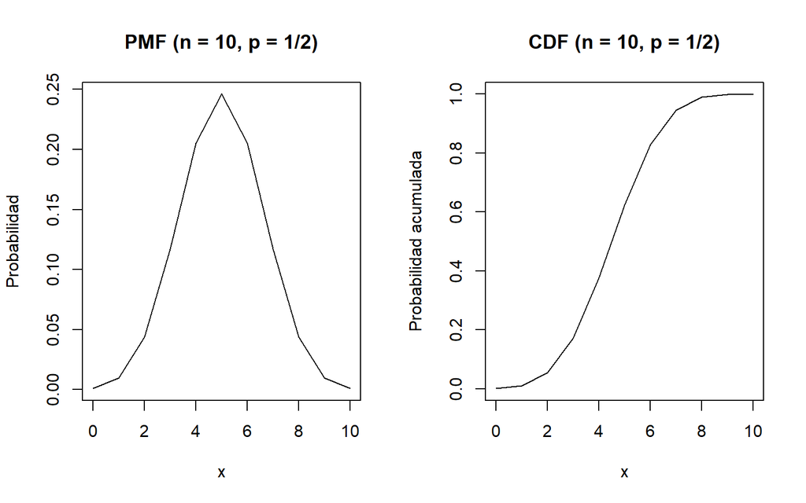

```r
n <- 10
p <- 1/2
x <- 0:n
pmf <- dbinom(x, size = n, prob = p)
cdf <- pbinom(x, size = n, prob = p)
par(mfrow = c(1, 2))
plot(x, pmf, type = "l", main = "PMF (n = 10, p = 1/2)", xlab = "x", ylab = "Probabilidad")
plot(x, cdf, type = "l", main = "CDF (n = 10, p = 1/2)", xlab = "x", ylab = "Probabilidad acumulada")
```

2. $n=10$ y $p=1/8$

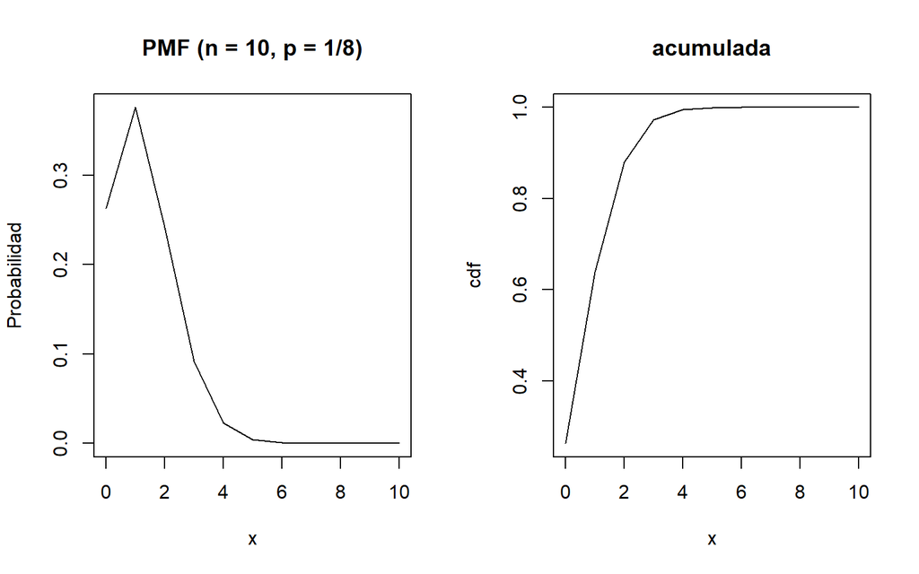

```r
n <- 10
p <- 1/8
x <- 0:n
pmf <- dbinom(x, size = n, prob = p)
cdf <- pbinom(x, size = n, prob = p)
par(mfrow = c(1, 2))
plot(x, pmf, type = "l", main = "PMF (n = 10, p = 1/8)", xlab = "x", ylab = "Probabilidad")
plot(x, cdf, type = "l", main = "acumulada")
```

3. $n=10$ y $p=4/5$

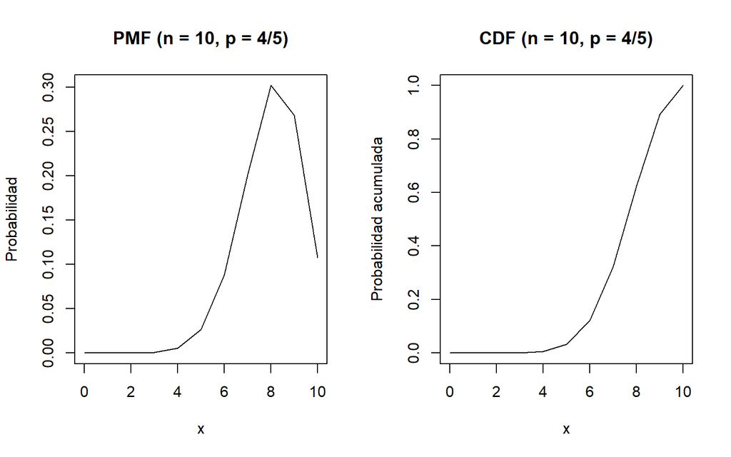

```r
n <- 10
p <- 4/5
x <- 0:n
pmf <- dbinom(x, size = n, prob = p)
cdf <- pbinom(x, size = n, prob = p)
par(mfrow = c(1, 2))
plot(x, pmf, type = "l", main = "PMF (n = 10, p = 4/5)", xlab = "x", ylab = "Probabilidad")
plot(x, cdf, type = "l", main = "CDF (n = 10, p = 4/5)", xlab = "x", ylab = "Probabilidad acumulada")
```

4. $n=10$ y $p=1/2$

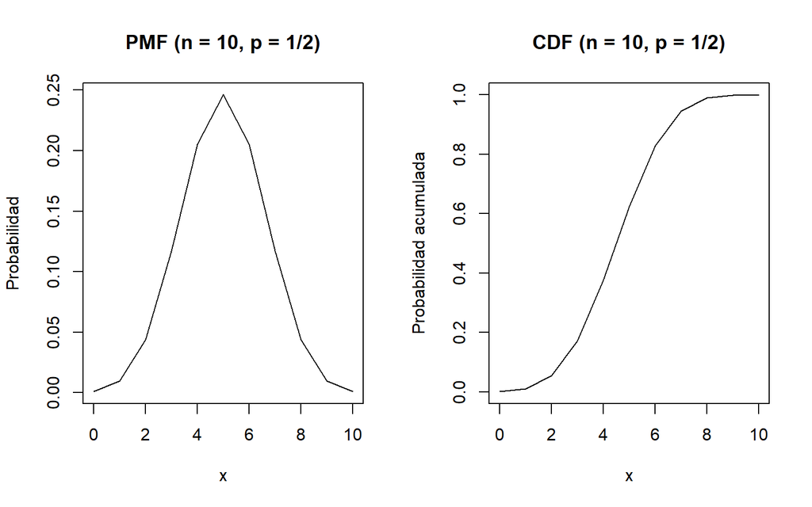

```r
n <- 10
p <- 1/2
x <- 0:n
pmf <- dbinom(x, size = n, prob = p)
cdf <- pbinom(x, size = n, prob = p)
par(mfrow = c(1, 2))
plot(x, pmf, type = "l", main = "PMF (n = 10, p = 1/2)", xlab = "x", ylab = "Probabilidad")
plot(x, cdf, type = "l", main = "CDF (n = 10, p = 1/2)", xlab = "x", ylab = "Probabilidad acumulada")
```

5. ¿Tiene algún efecto $n$ y $p$ para que la pmf sea simétrica? ¿Cuál?

El parámetro $p$ tiene un efecto significativo en la simetría de la PMF de la distribución binomial. Cuando $p=1/2$, la PMF es simétrica. Cuando $p$ es diferente de 1/2, la PMF es asimétrica, y la dirección de la asimetría depende de si $p$ es mayor o menor que 1/2. El parámetro $n$ controla la dispersión de la distribución, pero no afecta directamente a la simetría.

6. ¿Qué efecto tiene $p$ en la asimetría?

# Variables aleatorias continuas

Las variables aleatorias continuas, a diferencia de las discretas, quedan totalmente definidas mediante su PDF y CDF. Existen múltiples variables aleatorias bien conocidas y que sirven para modelar diversos fenómenos. La densidad Gamma está dada por la siguiente ecuación:
$$f_X(x, \alpha, \beta) = \begin{cases}
\frac{\beta^{\alpha}}{\Gamma(\alpha)} x^{\alpha-1} \mbox{e}^{-\beta x}
& x>0\\
0 & x\le 0
\end{cases}$$
donde $\alpha>0$ y $\beta >0$.

## Actividad

1. ¿Qué efecto tiene incrementar $\alpha$? Grafique para contestar.

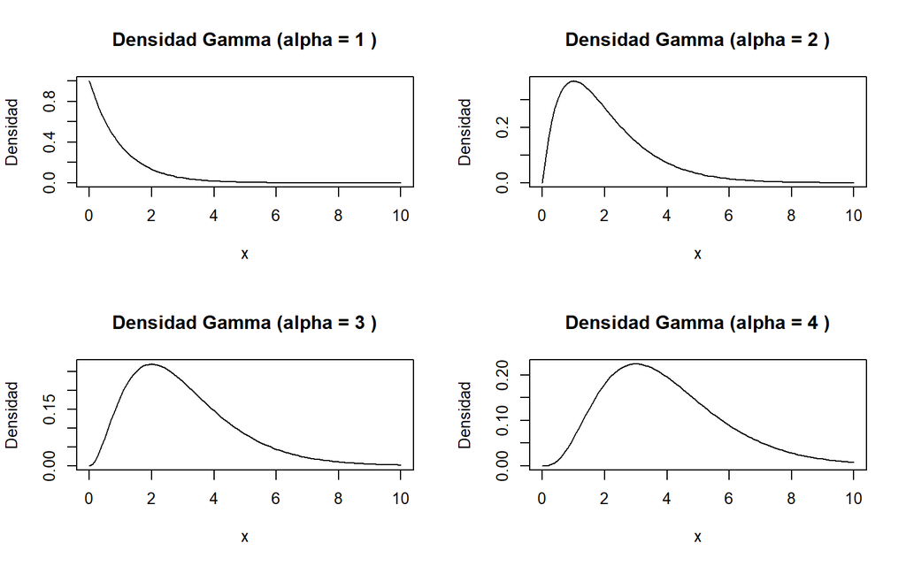

```r
# Definir los parámetros de la densidad Gamma
alpha_values <- c(1, 2, 3, 4)
beta <- 1

# Crear una función para la densidad Gamma
gamma_density <- function(x, alpha) {
  return((beta^alpha / gamma(alpha)) * x^(alpha - 1) * exp(-beta * x))
}

# Crear una nueva ventana gráfica
par(mfrow = c(2, 2))

# Graficar la densidad Gamma para diferentes valores de alpha
for (alpha in alpha_values) {
  curve(gamma_density(x, alpha), from = 0, to = 10, main = paste("Densidad Gamma (alpha =", alpha, ")"), xlab = "x", ylab = "Densidad")
}
```

2. ¿Qué efecto tiene $\beta$ en la forma de la densidad? Grafique para contestar.

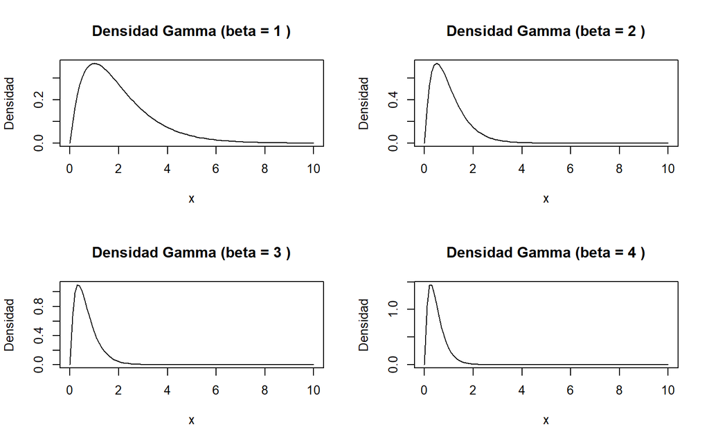

```r
# Definir los parámetros de la densidad Gamma
alpha <- 2
beta_values <- c(1, 2, 3, 4)

# Crear una función para la densidad Gamma
gamma_density <- function(x, beta) {
  return((beta^alpha / gamma(alpha)) * x^(alpha - 1) * exp(-beta * x))
}

# Crear una nueva ventana gráfica
par(mfrow = c(2, 2))

# Graficar la densidad Gamma para diferentes valores de beta
for (beta in beta_values) {
  curve(gamma_density(x, beta), from = 0, to = 10, main = paste("Densidad Gamma (beta =", beta, ")"), xlab = "x", ylab = "Densidad")
}
```

El efecto de $\beta$ en la densidad Gamma es reducir la escala de la distribución y desplazarla hacia la izquierda dentro del eje x.

Otra variable aleatoria de interés es la variable aleatoria de Cauchy que está definida de la siguiente manera:

$$f_X(x) = \frac{\beta}{\pi ([x-\alpha]^2 + \beta^2)}$$
donde $\alpha \in \mathbb{R}$ y $\beta >0$. Supógamos que $\alpha = 5$.

## Actividad

1. ¿Qué efecto tiene $\beta$ en la función de densidad? Grafique para contestar.

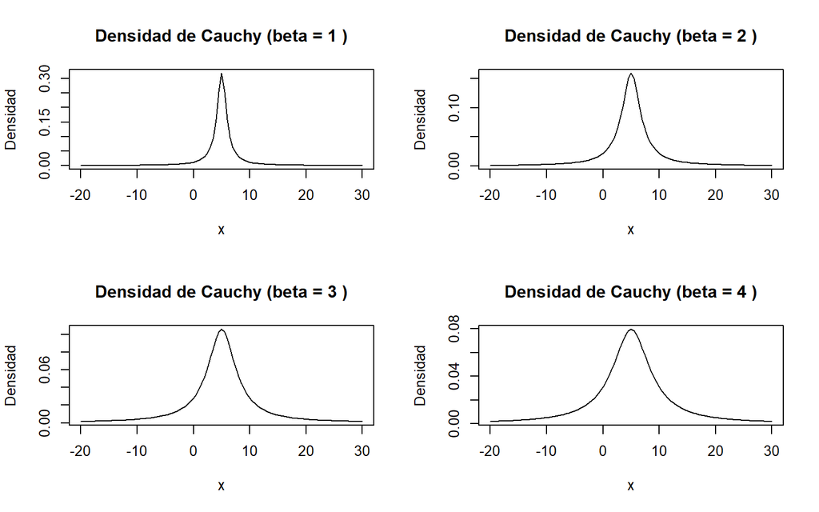

```r
# Parámetros
alpha <- 5
beta_values <- c (1, 2, 3, 4)

# Función de densidad de Cauchy
cauchy_density <- function(x, alpha, beta) {
  return(beta / (pi * ((x - alpha)^2 + beta^2)))
}

# Crear una nueva ventana gráfica
par(mfrow = c(2, 2))

# Graficar la densidad de Cauchy para diferentes valores de beta
for (beta in beta_values) {
  curve(cauchy_density(x, alpha, beta), from = -20, to = 30, main = paste("Densidad de Cauchy (beta =", beta, ")"), xlab = "x", ylab = "Densidad")
}
```

El parámetro $\beta$ en la función de densidad de la variable aleatoria de Cauchy afecta la escala y la forma de la distribución.

Supóngamos que tenemos la siguiente PDF:
$$f_X(x) = \begin{cases}
0 & x < a\\
\frac{2(x-a)}{(b-a)(c-a)} & a \le x < c\\
\frac{2}{b-a} & x=c\\
\frac{2(b-x)}{(b-a)(b-c)} & c < x \le b\\
0 & b < x
\end{cases}$$
donde $a < c < c$.